# In-class exercise for week 5-1

## 1. Tuples

A tuple1 is a sequence of values much like a list. The values stored in a tuple can be any type, and they are indexed by integers. The important difference is that tuples are immutable. Tuples are also comparable and hashable so we can sort lists of them and use tuples as key values in Python dictionaries.

```python
l1=[1,2,3,4,5]
print(l1[1:3])
```

```
[2, 3]
```

```python
l1[-1]
```

```
5
```

```python
l1[1:]
```

```
[2, 3, 4, 5]
```

Tuples are like lists in many ways!

```python
l1[::-1]
```

```
[5, 4, 3, 2, 1]
```

```python
l1[1::]
```

```
[2, 3, 4, 5]
```

```python
t1=1,2,3
type(t1)
```

```
tuple
```

```python
t2=(1,2,3)
type(t2)
```

```
tuple
```

```python
t3=1,2,3,4,5
t4=t1+t3
print(t4)
```

```
(1, 2, 3, 1, 2, 3, 4, 5)
```

```python
len(t4)
```

```
8
```

```python
t4[1:]
```

```
(2, 3, 1, 2, 3, 4, 5)
```

```python
t3[3:]
```

```
(4, 5)
```

```python
max(t4)
```

```
5
```

```python
min(t4)
```

```
1
```

```python
if 7 in t4:
    print("seven here")
else:
    print("no seven")
```

```
no seven
```

```python
t5=tuple("great")
print(t5)
```

```
('g', 'r', 'e', 'a', 't')
```

```python
t6=(2)
type(t6)
```

```
int
```

Once a tuple is created, you cannot change its values. Tuples are unchangeable, or immutable as it also is called.

```python
t5.append(6)
```

[output not shown]

```python
t5.insert(1,5)
```

[output not shown]

#### Question 1

step1) create `tuple1` as follows: tuple1 = (11, 22, 33, 44, 55, 66)

step 2) print 44 and 55

```python
tuple1=(11,22,33,44,55,66)
print(tuple1[3:5])
```

```
(44, 55)
```

## 2. Dictionaries

Dictionaries are the best! Their syntax is similar to a list and, like a list, a dictionary holds any number of values. Dictionaries are different, however, because instead of holding values at index locations dictionaries use *keys*. Imagine you wanted to store a collection of scientific names of animals. You would like to retrieve the scientific name of an animal using it's common name. In other words, if you type "Lion" into your search tool it gives you "Panthera Leo" as a result. A dictionary is exactly what you need. Think of a dictionary like this:

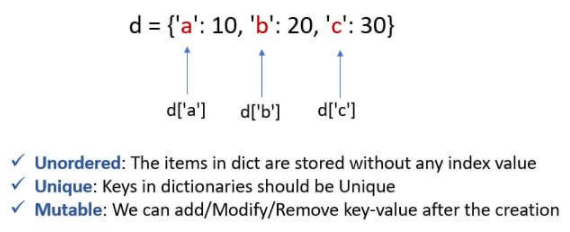

### 2-1. Create a Dictionary

Dictionaries are declared with key/value pairs separated by colons. Here's an example:

```
animals = { 'Lion': 'Panthera Leo',
           'Tiger': 'Panthera Tigris',
           'Bear': 'Ursus Arctos',
          }
```

In the example above I separated the animals onto different lines to make it more readable. It's just as valid to do it all on one line like this:

```
animals = {'Lion': 'Panthera Leo', 'Tiger': 'Panthera Tigris', 'Bear': 'Ursus Arctos',}
```

Pick your favorite example and type it into the next cell:

```python
animals = {'Lion': 'Panthera Leo', 'Tiger': 'Panthera Tigris', 'Bear': 'Ursus Arctos',}
```

```python
type(animals)
```

```
dict
```

```python
animals["Lion"]
```

```
'Panthera Leo'
```

```python
thingstodo={1:'coding',2:'reading a book',3:'shower'}
type(thingstodo)
```

```
dict
```

```python
thingstodo[1]
```

```
'coding'
```

Just like a list, a dictionary can be empty. Here's how you create an empty dictionary:

```
animals = {}
```

Dictionaries are their own type in Python. Here's how you use the `type` function to discover what type a dictionary is:

```
print(type(animals))
```

Try it:

```python
animals={}
print(type(animals))
```

```
<class 'dict'>
```

### 2-2 Access, Add and Remove Dictionary Elements

Dictionaries are accessed just like lists but with keys between the `[` and `]` brackets. For example:

```
print(animals['Lion'])
print(animals['Tiger'])
print(animals['Bear'])
```

Use the `print` function to access one of the animals in the `animals` dictionary:

```python
print(animals['Lion'])
```

```
Panthera Leo
```

```python
print(animals['Tiger'])
```

```
Panthera Tigris
```

```python
print(animals['Bear'])
```

```
Ursus Arctos
```

Dictionary elements are created at any time. For example, we here's how you create an element to hold the scientific name of the common house cat:

```
animals['Cat'] = 'Felis Silvestris Silvesteris'
```

Dictionary elements are reassigned when they appear on the left of the equal sign:

```
animals['Bear'] = 'Ursus Arctos Horribilis' # Grizzly Bear
```

```python
animals['Cat'] = 'Felis Silvestris Silvesteris'
print(animals)
```

```
{'Lion': 'Panthera Leo', 'Tiger': 'Panthera Tigris', 'Bear': 'Ursus Arctos', 'Cat': 'Felis Silvestris Silvesteris'}
```

```python
animals['Bear'] = 'Ursus Arctos Horribilis' # Grizzly Bear
print(animals)
```

```
{'Lion': 'Panthera Leo', 'Tiger': 'Panthera Tigris', 'Bear': 'Ursus Arctos Horribilis', 'Cat': 'Felis Silvestris Silvesteris'}
```

```python
thingstodo[4]='sleep'
print(thingstodo)
```

```
{1: 'coding', 2: 'reading a book', 3: 'shower', 4: 'sleep'}
```

Dictionary elements can be deleted with the `del` operator, just like with a list.

```
del animals['Lion']
```

The `clear` function remove all of the elements of a dictionary:

```
animals.clear()
```

Practice adding, changing and removing items from the `animals` dictionary:

```python
del animals['Lion']
```

```python
print(animals)
```

[output not shown]

```python
animals[1:1]
```

```
---------------------------------------------------------------------------
TypeError                                 Traceback (most recent call last)
<ipython-input-53-47061a8f5df7> in <module>
----> 1 animals[1:1]

TypeError: unhashable type: 'slice'
```

```python
del thingstodo[1]
```

```python
print(thingstodo)
```

```
{2: 'reading a book', 3: 'shower', 4: 'sleep'}
```

```python
print(thingstodo.keys())
```

```
dict_keys([2, 3, 4])
```

```python
print(thingstodo.values())
```

```
dict_values(['reading a book', 'shower', 'sleep'])
```

### 2-3 Dictionary Length

Just like with lists the `len` operator tells you how many *key/value pairs* are in a dictionary.

Enter the example code into the next cell:

```python
len(thingstodo)
```

```
3
```

### 2-4 Searching for Keys with `in`

The `in` operator works on dictionaries. It looks through the keys for one that matches.

```python
if "Bear" in animals:
    print("bear!")
else:
    print("nope")
```

```
bear!
```

### 2-5 Iterating Through Dictionaries with `for`

A dictionary can be three related sequences when used with a `for` loop:

1. A sequence of *values*
2. A sequence of *keys*
3. A sequence of *key/value pairs*

```python
for k in animals.values():
    print(k)
```

```
Panthera Tigris
Ursus Arctos
```

#### Question 2

Create the `courses` dictionary with the course number as key and the course name as value. For instance, BAN4550 is the key and Analytics Programming is the value.

Create ones based on what you are currently taking.

```python
courses={"BAN4550":"Analytics Programming","BAN4500":"ISFA","BAN":"Managerial Statistics","BAN4600:ISMA"}
```

#### Question 3

Use the `courses` dictionary you created. Write a `print` statement that prints the title of `BAN4550`.

```python
print("BAN4550")
```

```
BAN4550
```